# Deep Learning for Fetal Health Prediction: A Multiclass Classification Approach Using Cardiotocography Data

```python
# Data Handling & Preprocessing
import pandas as pd
import numpy as np
from sklearn.utils.class_weight import compute_class_weight
from sklearn.model_selection import train_test_split, StratifiedKFold
from sklearn.preprocessing import MinMaxScaler
from sklearn.dummy import DummyClassifier

# Metrics & Evaluation
from sklearn.metrics import balanced_accuracy_score, f1_score, precision_score, recall_score, confusion_matrix, ConfusionMatrixDisplay

# Visualization
import seaborn as sns
import matplotlib.pyplot as plt

# TensorFlow & Keras
import tensorflow as tf
from tensorflow.keras.models import Sequential
from tensorflow.keras.layers import Dense, Input, Dropout
from tensorflow.keras.optimizers import RMSprop, Adam, SGD
from tensorflow.keras.metrics import Precision, Recall, F1Score
from tensorflow.keras.regularizers import l2
from tensorflow.keras.utils import to_categorical
from tensorflow.keras.callbacks import EarlyStopping
```

## 1. Introduction

### 1.1 Understanding the Problem

Fetal health is a critical aspect of maternal and neonatal care, as it directly impacts the well-being of both the mother and the unborn child. Detecting fetal health problems early is important for reducing the risk of newborn deaths, as many of these deaths can be prevented with timely medical care. During pregnancy, continuous monitoring of fetal well-being helps detect potential complications, such as fetal distress, abnormal heart rate patterns, and oxygen deprivation, which can lead to serious birth complications, including preterm labor or stillbirth, if not addressed in time.

Currently, fetal health assessment relies on cardiotocography (CTG), a simple and cost-effective method for monitoring fetal heart rate, uterine contractions, and other vital signs. However, manually interpreting CTG readings can be challenging and prone to human error, which may lead to the misclassification of high-risk cases. As a result, developing an automated system that can accurately classify fetal health into categories can assist healthcare professionals in making timely and informed decisions.

By leveraging deep learning techniques, fetal health classification can be improved through automated pattern recognition, enhancing diagnostic accuracy. An automated classification system can support healthcare professionals in making timely, data-driven decisions while also enabling early interventions that can prevent complications during labor and delivery, ultimately improving overall maternal and neonatal health outcomes.

### 1.2 Aims and Objectives

The objectives of this project are:

- Analyze the dataset to understand its structure, distributions, and key patterns.
- Preprocess the data by normalizing features, converting it into tensors, and splitting it into training, validation, and test sets.
- Define the evaluation metrics and establish a naive baseline for comparison.
- Develop a baseline model to set a reference performance for the task.
- Train an overfitting model to observe its behavior and understand its limitations.
- Apply regularization techniques and fine-tune hyperparameters to improve generalization.
- Train and evaluate the optimized final model using the best hyperparameters.
- Assess the final model’s performance on the test set and compare it with previous results.

### 1.3 About the Dataset

This study utilizes the [Fetal Health Classification dataset](https://www.kaggle.com/datasets/andrewmvd/fetal-health-classification) dataset, originally sourced from The Journal of Maternal-Fetal Medicine and made publicly available by Andrew Mvd on Kaggle. The dataset consists of 2,126 records containing features extracted from Cardiotocography (CTG) exams. Each record has been classified by three expert obstetricians into one of three categories:

- **Normal**: No signs of fetal distress
- **Suspect**: Potential irregularities requiring further monitoring
- **Pathological**: High-risk cases requiring immediate medical attention on

This dataset is highly suitable for this study as it provides comprehensive fetal health indicators, including fetal heartbeat data, along with accelerations, decelerations, and abnormal short-term and long-term variability. It also contains information on fetal movement and uterine contractions, which are crucial for assessing fetal oxygen levels and overall health. Additionally, the dataset provides statistical features such as the mean, median, variance, trend, number of peaks, and number of zero crossings in the exam’s histogram. Most importantly, the dataset includes a categorical label for fetal health, Ensuring that each record is accurately assigned to one of the three categories by medical experts.

```python
# Load dataset
file_path = "fetal_health.csv"
df = pd.read_csv(file_path)

# Display first few rows
df.head()
```

|  | baseline value | accelerations | fetal_movement | uterine_contractions | light_decelerations | severe_decelerations | prolongued_decelerations | abnormal_short_term_variability | mean_value_of_short_term_variability | percentage_of_time_with_abnormal_long_term_variability | ... | histogram_min | histogram_max | histogram_number_of_peaks | histogram_number_of_zeroes | histogram_mode | histogram_mean | histogram_median | histogram_variance | histogram_tendency | fetal_health |
| --- | --- | --- | --- | --- | --- | --- | --- | --- | --- | --- | --- | --- | --- | --- | --- | --- | --- | --- | --- | --- | --- |
| 0 | 120.0 | 0.000 | 0.0 | 0.000 | 0.000 | 0.0 | 0.0 | 73.0 | 0.5 | 43.0 | ... | 62.0 | 126.0 | 2.0 | 0.0 | 120.0 | 137.0 | 121.0 | 73.0 | 1.0 | 2.0 |
| 1 | 132.0 | 0.006 | 0.0 | 0.006 | 0.003 | 0.0 | 0.0 | 17.0 | 2.1 | 0.0 | ... | 68.0 | 198.0 | 6.0 | 1.0 | 141.0 | 136.0 | 140.0 | 12.0 | 0.0 | 1.0 |
| 2 | 133.0 | 0.003 | 0.0 | 0.008 | 0.003 | 0.0 | 0.0 | 16.0 | 2.1 | 0.0 | ... | 68.0 | 198.0 | 5.0 | 1.0 | 141.0 | 135.0 | 138.0 | 13.0 | 0.0 | 1.0 |
| 3 | 134.0 | 0.003 | 0.0 | 0.008 | 0.003 | 0.0 | 0.0 | 16.0 | 2.4 | 0.0 | ... | 53.0 | 170.0 | 11.0 | 0.0 | 137.0 | 134.0 | 137.0 | 13.0 | 1.0 | 1.0 |
| 4 | 132.0 | 0.007 | 0.0 | 0.008 | 0.000 | 0.0 | 0.0 | 16.0 | 2.4 | 0.0 | ... | 53.0 | 170.0 | 9.0 | 0.0 | 137.0 | 136.0 | 138.0 | 11.0 | 1.0 | 1.0 |

5 rows × 22 columns

## 2. Problem Definition and Dataset

In this section, we will define the problem statement, conduct an initial exploratory data analysis (EDA) to examine class balance and feature correlations, and identify potential challenges that may arise when using this dataset for our deep learning model.

### 2.1 Problem Statement

The model addresses the challenge of accurately identifying potential fetal distress by developing a deep learning model that automates the classification of fetal health status based on cardiotocography (CTG) data. By leveraging various fetal heart rate and uterine contraction features, the model can help medical professionals in diagnostics by predicting whether a fetus is in a normal, suspect, or pathological state.

This is a single-label, multi-class classification problem in which the model assigns one of three discrete labels to each input sample. It is designed to distinguish between different fetal health conditions based on the provided data. The model processes numerical features extracted from CTG exams and outputs a classification label indicating fetal health status as normal (1), suspect (2), or pathological (3).

### 2.2 Dataset Overview

This dataset consists of 2,126 records, which is generally considered small for deep learning models. A limited dataset size can negatively impact model performance by increasing the risk of overfitting and reducing generalization ability.

The dataset contains 22 features, extracted from Cardiotocography (CTG) exams, which provide key insights into fetal health. These features include:

- **baseline value** – Baseline fetal heart rate (FHR)
- **accelerations** – Number of accelerations per second
- **fetal_movement** – Number of fetal movements per second
- **uterine_contractions** – Number of uterine contractions per second
- **light_decelerations** – Number of light decelerations per second
- **severe_decelerations** – Number of severe decelerations per second
- **prolongued_decelerations** – Number of prolonged decelerations per second
- **abnormal_short_term_variability** – Percentage of time with abnormal short-term variability
- **mean_value_of_short_term_variability** – Mean value of short-term variability
- **percentage_of_time_with_abnormal_long_term_variability** – Percentage of time with abnormal long-term variability
- **mean_value_of_long_term_variability** – Mean value of long-term variability
- **histogram_width** – Width of the histogram generated from all values in a record
- **histogram_min** – Minimum value in the histogram
- **histogram_max** – Maximum value in the histogram
- **histogram_number_of_peaks** – Number of peaks in the histogram
- **histogram_number_of_zeroes** – Number of zeroes in the histogram
- **histogram_mode** – Mode of the histogram
- **histogram_mean** – Mean value of the histogram
- **histogram_median** – Median value of the histogram
- **histogram_variance** – Variance of the histogram
- **histogram_tendency** – Trend of the histogram
- **fetal_health** – Fetal health classification:
  - 1 – Normal
  - 2 – Suspect
  - 3 – Pathological

Next, we will explore the dataset further using the .info() and .describe() functions from the pandas library to gain insights into its structure and statistical properties.

```python
# Check for missing values and data types
print(df.info())

# Show summary statistics of numerical features
print(df.describe())
```

```
<class 'pandas.core.frame.DataFrame'>
RangeIndex: 2126 entries, 0 to 2125
Data columns (total 22 columns):
 #   Column                                                  Non-Null Count  Dtype
---  ------                                                  --------------  -----
 0   baseline value                                          2126 non-null   float64
 1   accelerations                                           2126 non-null   float64
 2   fetal_movement                                          2126 non-null   float64
 3   uterine_contractions                                    2126 non-null   float64
 4   light_decelerations                                     2126 non-null   float64
 5   severe_decelerations                                    2126 non-null   float64
 6   prolongued_decelerations                                2126 non-null   float64
 7   abnormal_short_term_variability                         2126 non-null   float64
 8   mean_value_of_short_term_variability                    2126 non-null   float64
 9   percentage_of_time_with_abnormal_long_term_variability  2126 non-null   float64
 10  mean_value_of_long_term_variability                     2126 non-null   float64
 11  histogram_width                                         2126 non-null   float64
 12  histogram_min                                           2126 non-null   float64
 13  histogram_max                                           2126 non-null   float64
 14  histogram_number_of_peaks                               2126 non-null   float64
 15  histogram_number_of_zeroes                              2126 non-null   float64
 16  histogram_mode                                          2126 non-null   float64
 17  histogram_mean                                          2126 non-null   float64
 18  histogram_median                                        2126 non-null   float64
 19  histogram_variance                                      2126 non-null   float64
 20  histogram_tendency                                      2126 non-null   float64
 21  fetal_health                                            2126 non-null   float64
dtypes: float64(22)
memory usage: 365.5 KB
None
       baseline value  accelerations  fetal_movement  uterine_contractions  \
count     2126.000000    2126.000000     2126.000000           2126.000000
mean       133.303857       0.003178        0.009481              0.004366
std          9.840844       0.003866        0.046666              0.002946
min        106.000000       0.000000        0.000000              0.000000
25%        126.000000       0.000000        0.000000              0.002000
50%        133.000000       0.002000        0.000000              0.004000
75%        140.000000       0.006000        0.003000              0.007000
max        160.000000       0.019000        0.481000              0.015000

```

[output cut: 46 more lines]

```
50%                      0.000000      139.000000      136.000000
75%                      0.000000      148.000000      145.000000
max                     10.000000      187.000000      182.000000

       histogram_median  histogram_variance  histogram_tendency  fetal_health
count       2126.000000         2126.000000         2126.000000   2126.000000
mean         138.090310           18.808090            0.320320      1.304327
std           14.466589           28.977636            0.610829      0.614377
min           77.000000            0.000000           -1.000000      1.000000
25%          129.000000            2.000000            0.000000      1.000000
50%          139.000000            7.000000            0.000000      1.000000
75%          148.000000           24.000000            1.000000      1.000000
max          186.000000          269.000000            1.000000      3.000000

[8 rows x 22 columns]
```

As observed from the dataset summary provided by the .info() and .describe() functions, this dataset contains no missing values, and all features are numerical with varying ranges. The data is generally clean, with each feature represented by a single numerical value, meaning one-hot encoding is not required.

However, since the features have different value ranges, it is necessary to scale and normalize the data to ensure that all values fall within a consistent range (0-1). This helps improve model performance by preventing features with larger magnitudes from dominating those with smaller scales.

### 2.3 Data Exploration

#### 2.3.1 Class Distribution analysis

Now, we will examine the class distribution of the dataset. Understanding class distribution helps identify potential imbalances, which can influence the selection of appropriate evaluation metrics for assessing model performance. It also provides insights that can guide the choice of model parameters and structure to ensure better handling of imbalanced data.

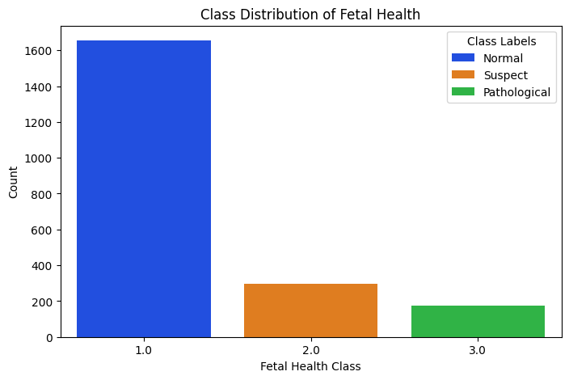

```
{1.0: '77.85%', 2.0: '13.88%', 3.0: '8.28%'}
```

```python
# Visualize class distribution
plt.figure(figsize=(8, 5))
ax = sns.countplot(x=df['fetal_health'], hue=df['fetal_health'], palette="bright")

# Add legend with class names
class_mapping = {1: "Normal", 2: "Suspect", 3: "Pathological"}
handles, labels = ax.get_legend_handles_labels()
plt.legend(handles, class_mapping.values(), title="Class Labels")

# Labels and title
plt.title("Class Distribution of Fetal Health")
plt.xlabel("Fetal Health Class")
plt.ylabel("Count")

# Show the plot
plt.show()

# Compute class percentages
fetal_health_percentage = df['fetal_health'].value_counts(normalize=True) * 100
formatted_fetal_health_percentage = fetal_health_percentage.apply(lambda x: f"{x:.2f}%")

# Print class distribution percentages
print(formatted_fetal_health_percentage.to_dict())
```

The class distribution plot above shows that the dataset is highly imbalanced, with Class 1 (Normal) dominating at 77.85%, followed by Class 2 (Suspect) at 13.88%, and Class 3 (Pathological) at 8.28%. This imbalance can cause the model to favor predicting the majority class (Normal), making it difficult to learn patterns for the underrepresented classes (Suspect and Pathological). To address this issue, we can apply class weights during training, adjusting the importance of each class to improve learning for minority classes and ensure a more balanced model performance.

#### 2.3.2 Correlation Analysis

Next, we will examine the correlation between features to understand their relationships with each other and with fetal_health. This analysis helps identify which features are most relevant for fetal health classification and how they influence the model’s decision-making. Additionally, it can guide us in selecting the most important features for model training and optimization.

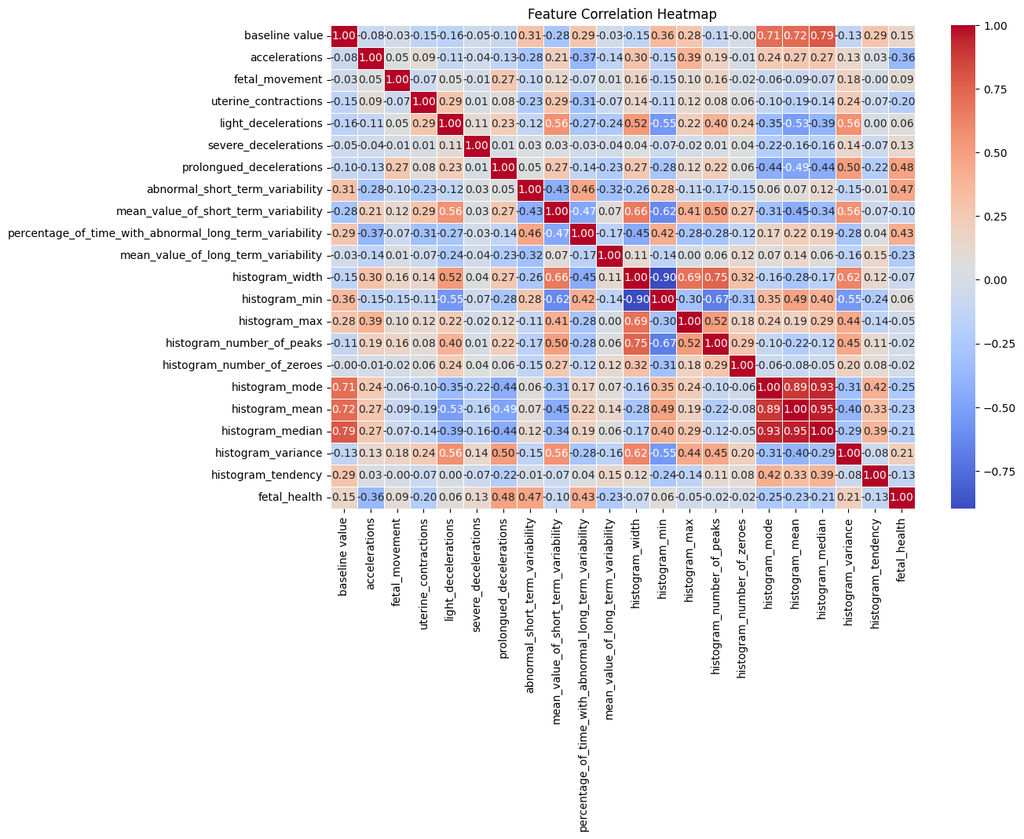

```python
# Compute correlation matrix
correlation_matrix = df.corr()

# Set figure size
plt.figure(figsize=(12, 8))

# Generate a heatmap
sns.heatmap(correlation_matrix, annot=True, cmap="coolwarm", fmt=".2f", linewidths=0.5)

# Title and display
plt.title("Feature Correlation Heatmap")
plt.show()
```

According to the heatmap above, prolonged_decelerations has the highest positive correlation with fetal_health at 0.48, suggesting that prolonged decelerations in fetal heart rate may indicate a higher risk of fetal distress. This is followed by abnormal_short_term_variability (0.47), indicating that short-term fluctuations in heart rate are linked to fetal health risks, and percentage_of_time_with_abnormal_long_term_variability (0.43), which may affect fetal health due to irregular heartbeat patterns.

Similarly, accelerations has the highest negative correlation with fetal_health at -0.36, suggesting that frequent accelerations in heart rate are associated with healthier fetal conditions. This is followed by histogram_mode (-0.25), which indicates that lower values in these histogram statistics correlate with better fetal health. Lastly, mean_value_of_long_term_variability (-0.23) suggests that normal long-term variability is a sign of a healthy fetus.

### 2.4 Potential challenges

#### 2.4.1 Class Imbalance

Since the dataset is imbalanced, it can lead to biased model predictions, where the model favors the majority class, resulting in poor generalization and high classification error rates for minority classes.To address this issue, class weights can be applied during training to ensure that the model treats all classes more equally. Additionally, accuracy should not be used as the primary evaluation metric, as a model can achieve high accuracy simply by predicting the majority class, making it a misleading measure of performance.

#### 2.4.2 Noise in FHR Patterns

Fetal heart rate (FHR) patterns can be influenced by external factors such as maternal conditions, stress, fetal movement, and measurement errors, introducing noise into cardiotocography (CTG) readings. This variability can affect the model’s accuracy by making it harder to distinguish meaningful patterns from random fluctuations. Inconsistent sensor readings or external disturbances may lead to misclassifications, especially in borderline cases. To minimize the impact of noise, data preprocessing techniques such as normalization, outlier removal, or smoothing methods can be applied to improve model reliability.

#### 2.4.3 Overfitting

Since this dataset is relatively small, it is susceptible to overfitting, where the model performs well on training data but struggles with new, unseen data. This leads to poor generalization and reduced transferability to real-world cases. When training on limited data, it is generally advisable to use a smaller neural network with only one or two hidden layers to minimize the risk of severe overfitting. Additionally, applying regularization techniques such as dropout, L2 weight decay, or data augmentation can further help improve model generalization.

#### 2.4.4 Generalization

Since the dataset is relatively small, it may not cover all possible pregnancy conditions, which could limit the model’s ability to perform well on different populations. As a result, the model may learn patterns specific to this dataset rather than identifying generalizable features applicable to real-world cases. To improve generalization, techniques such as cross-validation, data augmentation, and regularization can help the model learn more robust and transferable patterns. Additionally, evaluating the model on an external dataset or expanding the dataset with more diverse samples can further enhance its real-world applicability.

## 3. Choosing a Measure of Success

Here, we will select the most appropriate metrics to effectively evaluate model performance and define what constitutes success. As mentioned earlier, since we are dealing with a class-imbalanced problem, standard accuracy is not a reliable metric as it can be misleading. Instead, we will use alternative evaluation metrics that provide a more balanced assessment of model performance.

### 3.1 Balanced Accuracy

Balanced accuracy is the arithmetic mean of sensitivity (recall for the positive class) and specificity (recall for the negative class). It is equivalent to the macro-average of recall scores across all classes, ensuring that each class contributes equally to the final score. This makes it particularly useful for imbalanced datasets, as it prevents the model from being biased toward the majority class by applying equal weight to all classes.The formula for Balanced Accuracy is:

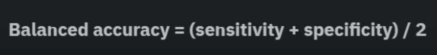

Sensitivity, also known as the true positive rate (TPR) or recall, measures the proportion of actual positive cases that are correctly identified by the model. Specificity, also known as the true negative rate (TNR), measures the proportion of correctly identified negative cases over the total actual negatives. Both can be calculated using the following formulas:

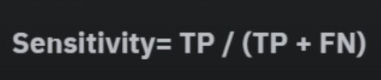

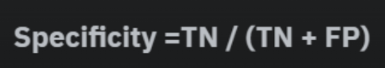

Since achieving 100% balanced accuracy is nearly impossible and unrealistic, a reasonable goal for this task is to achieve a balanced accuracy above 80%, indicating that the model performs well across all classes without being biased toward the majority class.

### 3.2 Precision

Precision measures the proportion of correctly predicted positive cases out of all cases the model classified as positive. It provides insight into the model’s ability to accurately identify positive instances while minimizing false positives. The formula for precision is:

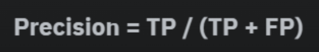

For this task, we aim to achieve a precision of over 80%, as this reflects a strong model with a low false positive rate.

### 3.3 Recall

Recall measures the proportion of correctly predicted positive cases out of all actual positive cases. It is a crucial metric in classification, especially for imbalanced datasets, as it evaluates the model’s ability to identify all relevant instances while minimizing false negatives. The formula for recall is:

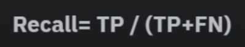

Since precision and recall are closely related, we can also aim for a recall of over 80%, as this indicates that the model is successfully capturing most positive cases.

### 3.4 F1 Score

The F1 score is a widely used metric for assessing the performance of a classification model. It balances Precision and Recall, focusing on a single class rather than the entire dataset. It is computed using the following formula:

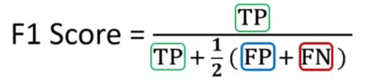

However, in the case of multi-class classification, we use Macro F1 score, which is the average of the F1 scores across all classes. It ensures balanced performance across all classes, preventing minority classes such as Suspect and Pathological from being overlooked. It is calculated using the formula:

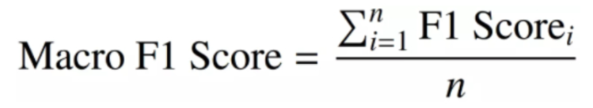

Since the F1 score balances precision and recall, we aim for a macro average of at least 75%, indicating that the model maintains a good trade-off between precision and recall across all classes.

## 4. Deciding on an Evaluation Protocol

In this section, we will define the evaluation protocol to measure model performance and track progress. Choosing appropriate metrics and validation strategies ensures the model generalizes effectively while addressing challenges such as class imbalance and overfitting.

### 4.1 Stratified K-fold Cross Validation

Unlike standard k-fold cross-validation, which splits the data randomly and may result in imbalanced folds, stratified k-fold ensures that each fold maintains the same class distribution as the full dataset. This prevents the model from overfitting to majority classes and improves generalization to unseen cases. By applying stratification, the model learns from diverse yet balanced subsets of the data, leading to a more stable and reliable evaluation across all folds. This approach ensures that performance metrics accurately reflect the model’s ability to classify both majority and minority classes, making it particularly useful for imbalanced datasets like this one.

### 4.2 Hold-Out Validation

Holdout validation is used in this task because it provides a reliable and computationally efficient method for evaluating model performance while preserving an unseen test set for the final assessment. It also helps prevent data leakage and overfitting, as using the entire dataset for training without setting aside a test set could lead to an overly optimistic performance estimate. By holding out a separate test set, we ensure that the final model is evaluated on completely unseen data, providing a realistic measure of its generalization ability.

### 4.3 Combined Approach: K-Fold and Holdout Evaluation

This hybrid approach combines stratified k-fold cross-validation and holdout validation to ensure a fair and unbiased final assessment of the model. First, stratified k-fold cross-validation is applied to the training data to evaluate multiple model configurations, fine-tune hyperparameters, and select the best-performing model. This process helps reduce variance and improve generalization, making the model more reliable.

Once the optimal model is identified, it is evaluated on the holdout test set, which remains unseen throughout training and validation. This final evaluation provides an objective measure of real-world performance, ensuring the model generalizes effectively without overfitting to the validation set.

## 5. Preparing Your Data

In this section, we will prepare the dataset for model training by computing class weights and formatting the data for input. This process involves calculating class weights to handle class imbalance, normalizing features to ensure consistent data scaling, and splitting the dataset into training, validation, and test sets. Additionally, the data will be explicitly converted into NumPy arrays, as we will be using NumPy functions, and TensorFlow accepts NumPy input for efficient processing.

### 5.1 Computing Class Weights

First, we compute the class weights using the compute_class_weight function from Scikit-Learn. This function adjusts class weights based on their frequency in the dataset, assigning higher weights to less frequent classes and lower weights to more common ones. It does this by dividing the total number of samples by the product of the number of classes and the number of samples in each class, ensuring that minority classes receive greater importance during training.

After computing the class weights, we convert the resulting NumPy array into a dictionary so that it can be used in TensorFlow during model training. We perform this step before normalization and data splitting to ensure that the computed weights accurately reflect the full dataset distribution.

```python
# Compute class weights for fetal_health column
class_weights = compute_class_weight(
    class_weight="balanced",
    classes=np.unique(df['fetal_health']),
    y=df['fetal_health']
)

# Convert NumPy array to dictionary format (needed for TensorFlow)
class_weight_dict = dict(zip(np.unique(df['fetal_health']), class_weights))

# Print computed class weights
print(class_weight_dict)
```

```
{1.0: 0.4281973816717019, 2.0: 2.4022598870056497, 3.0: 4.026515151515151}
```

### 5.2 Data Normalization

Next, we will normalize the data using the MinMaxScaler, which scales all feature values to a 0-1 range. MinMaxScaler is chosen because this dataset contains features with varying scales, such as fetal heart rate (baseline values) ranging from 106 to 160, while accelerations range from 0 to 0.019. Scaling ensures that all features contribute equally, preventing larger values from dominating smaller ones while preserving the original distribution of the data.

```python
num_features = df.drop(columns=['fetal_health']).columns

# Apply Min-Max Scaling
scaler = MinMaxScaler()
df[num_features] = scaler.fit_transform(df[num_features])

# Check scaled data
df.head()
```

|  | baseline value | accelerations | fetal_movement | uterine_contractions | light_decelerations | severe_decelerations | prolongued_decelerations | abnormal_short_term_variability | mean_value_of_short_term_variability | percentage_of_time_with_abnormal_long_term_variability | ... | histogram_min | histogram_max | histogram_number_of_peaks | histogram_number_of_zeroes | histogram_mode | histogram_mean | histogram_median | histogram_variance | histogram_tendency | fetal_health |
| --- | --- | --- | --- | --- | --- | --- | --- | --- | --- | --- | --- | --- | --- | --- | --- | --- | --- | --- | --- | --- | --- |
| 0 | 0.259259 | 0.000000 | 0.0 | 0.000000 | 0.0 | 0.0 | 0.0 | 0.813333 | 0.044118 | 0.472527 | ... | 0.110092 | 0.034483 | 0.111111 | 0.0 | 0.472441 | 0.587156 | 0.403670 | 0.271375 | 1.0 | 2.0 |
| 1 | 0.481481 | 0.315789 | 0.0 | 0.400000 | 0.2 | 0.0 | 0.0 | 0.066667 | 0.279412 | 0.000000 | ... | 0.165138 | 0.655172 | 0.333333 | 0.1 | 0.637795 | 0.577982 | 0.577982 | 0.044610 | 0.5 | 1.0 |
| 2 | 0.500000 | 0.157895 | 0.0 | 0.533333 | 0.2 | 0.0 | 0.0 | 0.053333 | 0.279412 | 0.000000 | ... | 0.165138 | 0.655172 | 0.277778 | 0.1 | 0.637795 | 0.568807 | 0.559633 | 0.048327 | 0.5 | 1.0 |
| 3 | 0.518519 | 0.157895 | 0.0 | 0.533333 | 0.2 | 0.0 | 0.0 | 0.053333 | 0.323529 | 0.000000 | ... | 0.027523 | 0.413793 | 0.611111 | 0.0 | 0.606299 | 0.559633 | 0.550459 | 0.048327 | 1.0 | 1.0 |
| 4 | 0.481481 | 0.368421 | 0.0 | 0.533333 | 0.0 | 0.0 | 0.0 | 0.053333 | 0.323529 | 0.000000 | ... | 0.027523 | 0.413793 | 0.500000 | 0.0 | 0.606299 | 0.577982 | 0.559633 | 0.040892 | 1.0 | 1.0 |

5 rows × 22 columns

### 5.3 Holdout Validation

Before performing holdout validation, we first need to one-hot encode the fetal_health labels to adjust them to start from 0, as they currently begin at 1. We achieve this using “to_categorical” from TensorFlow.

```python
# Define features and target
X = df.drop(columns=['fetal_health'])
y = df['fetal_health']

# Convert target (y) to one-hot encoding
y = to_categorical(y - 1, num_classes=3)  # Adjust labels to start from 0
```

Next, we will split the dataset into three sets: training, validation, and test sets using “train_test_split” from Scikit-Learn. 80% of the data will be allocated to the training set, where the model learns patterns from the data. From this, 10% will be used as the validation set, which helps fine-tune and evaluate the model during training. The remaining 20% will serve as the test set, which is reserved for the final evaluation to assess the model’s performance on unseen data.

```python
# Split data (80% training, 20% testing)
X_train, X_test, y_train, y_test = train_test_split(X, y, test_size=0.2, stratify=y, random_state=42)

# Further split data (90% training, 10% validation)
X_train, X_val, y_train, y_val = train_test_split(X_train, y_train, test_size=0.1, stratify=y_train, random_state=42)
```

### 5.4 Converting Data to NumPy Format

Lastly, we will explicitly convert all dataset splits, training, validation, and test sets into NumPy arrays to ensure compatibility with NumPy functions and TensorFlow models, which accept NumPy inputs.

```python
X_train = np.array(X_train, dtype=np.float32)
X_val = np.array(X_val, dtype=np.float32)
X_test = np.array(X_test, dtype=np.float32)
y_train = np.array(y_train, dtype=np.float32)
y_val = np.array(y_val, dtype=np.float32)
y_test = np.array(y_test, dtype=np.float32)

print("Training Data Shape:", X_train.shape)
print("Validation Data Shape:", X_val.shape)
print("Testing Data Shape:", X_test.shape)
```

```
Training Data Shape: (1530, 21)
Validation Data Shape: (170, 21)
Testing Data Shape: (426, 21)
```

## 6. Developing a Baseline Model

Here, we will define a naive baseline as a reference for comparison and develop a baseline model that outperforms it. This serves as a starting point for the classification task, providing an initial benchmark for model evaluation and improvement.

### 6.1 Naive Baseline

Before starting, we need to define a naive baseline, which is a simple, often overly simplistic model used as a reference point for comparison when evaluating more complex models. Although naive baselines make simplistic assumptions, they are useful for establishing a minimum performance benchmark.

For this task, we will use the “DummyClassifier" from Scikit-Learn along with “balanced_accuracy_score”, “f1_score”, “precision_score”, and “recall_score” as evaluation metrics. We will apply the “most_frequent” strategy, which always predicts the most frequent class in the training set. To prevent data leakage, we will train the naive baseline using only the training set rather than the entire dataset. The test set will remain exclusive for final evaluation, ensuring a fair comparison against later models. Using the entire dataset for the naive baseline would give it an unfair advantage, as real models will only be trained on a subset of the data.

```python
# Create a DummyClassifier using "most_frequent" strategy
dummy_clf = DummyClassifier(strategy="most_frequent")

# Fit the dummy classifier using integer labels
dummy_clf.fit(X_train, y_train.argmax(axis=1))

# Predict using the dummy classifier on the validation set
y_dummy_pred = dummy_clf.predict(X_val)

# Compute baseline metrics using validation set
naive_balanced_accuracy = balanced_accuracy_score(y_val.argmax(axis=1), y_dummy_pred)
naive_precision = precision_score(y_val.argmax(axis=1), y_dummy_pred, average='macro', zero_division=1)
naive_recall = recall_score(y_val.argmax(axis=1), y_dummy_pred, average='macro', zero_division=1)
naive_f1 = f1_score(y_val.argmax(axis=1), y_dummy_pred, average='macro')

# Print baseline performance
print("Naive Baseline")
print(f'Balanced Accuracy: {naive_balanced_accuracy:.2f}')
print(f'Precision (Macro): {naive_precision:.2f}')
print(f'Recall (Macro): {naive_recall:.2f}')
print(f'F1 Score (Macro): {naive_f1:.2f}')
```

```
Naive Baseline
Balanced Accuracy: 0.33
Precision (Macro): 0.93
Recall (Macro): 0.33
F1 Score (Macro): 0.29
```

As seen from the results above, the naive baseline model has a very low balanced accuracy of 0.33 because it predicts only the most frequent class, completely ignoring the minority classes. The precision of 0.93 is misleadingly high since the model rarely predicts minority classes, resulting in very few false positives but many false negatives. The recall of 0.33 is extremely poor, indicating that the model fails to detect most minority class instances, further confirming its bias toward the majority class and its inability to generalize. Additionally, the macro F1 score of 0.29, which balances precision and recall, reflects the overall poor performance of the model despite its seemingly high precision.

Since the precision and recall metrics are skewed due to the "most_frequent" strategy used by the Dummy Classifier, which never predicts the minority classes, they do not provide an accurate measure of performance. As a result, we will focus on comparing the naive baseline and the baseline model using balanced accuracy and macro F1 score, as these metrics offer a fairer assessment of overall model performance.

### 6.2 Baseline Model

After obtaining the naive baseline performance, we can proceed with developing the baseline model. This model should be designed to outperform the naive baseline while maintaining simplicity. To achieve this, we will use Keras to build our models, starting with a sequential model composed of dense layers. However, before constructing the baseline model, we must first determine several key hyperparameters that will influence its performance.

#### 6.2.1 Number of Layers

The number of layers in a neural network determines how well the model can capture complex patterns and relationships within the data. Each layer computes a weighted sum of inputs and passes it through an activation function in the hidden layers. The choice of layers depends on the dataset’s complexity. A single hidden layer is sufficient to approximate any function that maps one finite space to another, enabling the model to learn nonlinear relationships and intricate patterns. Adding a second hidden layer allows the network to approximate complex decision boundaries with arbitrary accuracy, increasing its flexibility. Since our dataset contains complex nonlinear patterns, we will begin with a single hidden layer for our baseline model. If necessary, additional layers can be introduced later to improve performance.

#### 6.2.2 Number of Hidden Neurons

The number of hidden neurons is determined based on the size of the input features and the nature of the task. The input layer contains as many neurons as there are features in the dataset, while the output layer corresponds to the number of class labels, as this is a multi-class classification problem. A common rule of thumb suggests that the number of hidden neurons should fall between the size of the input and output layers. One approach is to set it to approximately two-thirds of the input layer size plus the output layer size, which in this case results in 17 neurons. Another guideline is that the hidden layer should have fewer than twice the size of the input layer, which would be around 40 neurons.

Since we are building a baseline model that only needs to surpass the naive baseline, we will start with 16 hidden neurons, as it is a reasonable value. It is smaller than the input layer, close to the two-thirds rule, and well within the upper bound of 40. Therefore, our baseline model will consist of an input layer with 21 neurons, corresponding to the twenty-one features in our dataset, a hidden layer with 16 neurons, and an output layer with 3 neurons representing the class labels.

#### 6.2.3 Activation Functions

The activation function maps inputs to the desired output by transforming the weighted sum of inputs plus bias into a final output value. Without activation functions, neural networks would behave like simple linear regression models, limiting their ability to capture nonlinear relationships essential for solving real-world problems. ReLU (Rectified Linear Unit) is one of the most popular activation functions, as it enables neural networks to learn complex patterns efficiently and is widely used in deep learning applications.

The last-layer activation function is responsible for generating the final predictions of the model. It is critical because it determines how the output values are interpreted. Since this is a multiclass, single-label classification problem, the standard approach is to use the softmax activation function in the last layer. Softmax converts the raw output values into a probability distribution, ensuring that the sum of all output values equals one. The class with the highest probability is selected as the model’s final prediction, making softmax ideal for multiclass classification tasks.

#### 6.2.4 Loss Function

The loss function quantifies how far off the network’s predictions are from the actual target values by measuring the disparity between predicted and true outcomes. It guides the training process by computing errors and influencing parameter updates through backpropagation. In essence, the loss function evaluates how well the model is learning to represent the dataset. For this multiclass classification problem, we will use “categorical_crossentropy", which is the most commonly used loss function for such tasks. "categorical_crossentropy" computes the difference between the predicted probability distribution and the true class labels, making it an effective choice for optimizing multi-class models.

#### 6.2.5 Optimization Configuration

Optimizers adjust the model’s weights and learning rates to minimize error and improve performance. An optimization algorithm determines the values of the parameters (weights) that minimize the loss function when mapping inputs to outputs. Its primary role is to fine-tune the neural network’s parameters, ensuring the model learns effectively and converges to an optimal solution.

There are various types of optimizers, each with distinct update rules, learning rates, and momentum strategies. Some common ones include Stochastic Gradient Descent (SGD), Adam, and RMSprop. For our baseline model, we will use RMSprop with its default learning rate, as it is a widely effective choice for handling different types of machine learning problems and ensuring stable convergence.

#### 6.2.6 Epochs

An epoch refers to one complete pass of the entire training dataset through the model during training. The number of epochs is a critical hyperparameter, as it determines how many times the learning algorithm will iterate over the dataset. Training for a single epoch is usually insufficient to capture all the patterns in the data. By running multiple epochs, the model gradually learns and improves its performance as it refines the weights through repeated updates. For our baseline model, we will start with 30 epochs, as this provides a reasonable starting point. If necessary, we can adjust this number based on the model’s performance and convergence behavior.

#### 6.2.7 Batch Size

A batch refers to a subset of the training data that is processed together during one forward pass and one backward pass of the neural network because the entire dataset is often too large to process all at once, it is divided into smaller groups called batches. Batch size is a hyperparameter that defines the number of training examples included in one batch. It determines how much data is processed before the model updates its weights. Choosing the optimal batch size is crucial as it impacts training efficiency and model performance, allowing for better resource utilization and faster convergence. For starters, we can go with 32 as a good starting point as it provides a balance between stability and training speed and we can adjust accordingly later on based on the model’s performance

#### 6.2.8 Structure Overview

For our baseline model, we will use Keras to define a simple neural network with:

- **Input Layer**: Consists of 21 features (matching the dataset's feature count).
- **Hidden Layer**: A single dense layer with **16 neurons**, using the **ReLU activation function** to introduce non-linearity and help the model learn complex patterns.
- **Output Layer**: A dense layer with **3 neurons**, corresponding to the number of class labels. This layer uses the **softmax activation function**, which converts raw output values into a probability distribution, ensuring that the predicted class has the highest probability.

We will compile the model with:

- **Optimizer**: RMSprop (using its default learning rate).
- **Loss Function**: Categorical crossentropy, which is well-suited for multiclass classification.

We will evaluate the model with:

- **Balanced accuracy** (imported from sklearn).
- **Precision, recall, and macro F1 score** (calculated using TensorFlow).

For training, we will start with 30 epochs and a batch size of 32, adjusting these values based on the model’s performance. We will train the model using the training set and evaluate it using the validation set, keeping the test set unseen until the final model evaluation to ensure an unbiased assessment of generalization.

#### 6.2.9 Implementation

Since we will be repeating the implementation process throughout this study with different models, we can create functions to streamline the workflow and improve efficiency.

```python
# Function to compile the model with dynamic optimizer selection
def compile_model(model, learning_rate=0.001, optimizer_name="rmsprop"):
    # Choose the optimizer based on the optimizer_name parameter
    if optimizer_name == "rmsprop":
        optimizer = RMSprop(learning_rate=learning_rate)
    elif optimizer_name == "adam":
        optimizer = Adam(learning_rate=learning_rate)
    elif optimizer_name == "sgd":
        optimizer = SGD(learning_rate=learning_rate)
    else:
        raise ValueError(f"Unsupported optimizer: {optimizer_name}")

    # Compile the model with the chosen optimizer
    model.compile(
        optimizer=optimizer,
        loss="categorical_crossentropy",
        metrics=[
            Precision(name="precision"),
            Recall(name="recall"),
            F1Score(name="f1_score", average="macro")
        ]
    )

# Function to train the model (with flexible epochs for overfitting)
def train_model(model, X_train, y_train, X_val, y_val, epochs=30, batch_size=32, class_weight=None):
    history = model.fit(
        X_train, y_train,
        epochs=epochs,
        batch_size=batch_size,
        validation_data=(X_val, y_val),
        class_weight=class_weight,
        verbose=0
    )
    return history

# Function to evaluate the model
def evaluate_model(model, X_val, y_val):
    results = model.evaluate(X_val, y_val, batch_size=32, verbose=0)
    return results

# Function to get class predictions
def get_predictions(model, X_val, y_val):
    y_pred = model.predict(X_val, verbose=0).argmax(axis=1)
    y_true = y_val.argmax(axis=1)  # Convert one-hot labels back to integer class labels
    return y_pred, y_true

# Function to print evaluation results
def print_evaluation_results(balanced_acc, precision, recall, f1_score, y_pred):
    print(f"Balanced Accuracy: {balanced_acc:.2f}")
    print(f"Precision: {precision:.2f}")
    print(f"Recall: {recall:.2f}")
    print(f"F1 Score (Macro): {f1_score:.2f}")

    # Print class distribution in predictions
    unique, counts = np.unique(y_pred, return_counts=True)
    print("Prediction Distribution:", dict(zip(unique, counts)))

# Function to plot training vs validation loss
def plot_loss(training_history, plot_title="Training vs Validation Loss"):
    # Extract training and validation loss
    loss = training_history.history['loss']  # Training loss
    val_loss = training_history.history['val_loss']  # Validation loss

    # Get the number of epochs
    epochs = range(1, len(loss) + 1)

    # Plot training & validation loss as points and lines
    plt.figure(figsize=(8, 5))
    plt.plot(epochs, loss, 'r.-', label='Training Loss')  # Red points with line
    plt.plot(epochs, val_loss, 'b.-', label='Validation Loss')  # Blue points with line
    plt.xlabel('Epochs')
    plt.ylabel('Loss')
    plt.title(plot_title)  # Dynamic title
    plt.legend()
    plt.grid(True)
    plt.show()
```

Then, using these functions, we can build our model and evaluate its performance efficiently.

```python
# Define a simple baseline model
baseline_model = Sequential([
    Input(shape=(X_train.shape[1],)),
    Dense(16, activation='relu'),
    Dense(3, activation='softmax')
])

# Compile the model
compile_model(baseline_model)

# Train the model
baseline_history = train_model(baseline_model, X_train, y_train, X_val, y_val, class_weight=class_weight_dict)

# Evaluate the trained model
baseline_results = evaluate_model(baseline_model, X_val, y_val)

# Get class predictions
y_pred, y_true = get_predictions(baseline_model, X_val, y_val)

# Compute Balanced Accuracy
balanced_acc = balanced_accuracy_score(y_true, y_pred)

# Print evaluation results
print("Baseline Model")
print_evaluation_results(balanced_acc, baseline_results[1], baseline_results[2], baseline_results[3], y_pred)
```

```
Baseline Model
Balanced Accuracy: 0.68
Precision: 0.88
Recall: 0.81
F1 Score (Macro): 0.63
Prediction Distribution: {0: 141, 1: 6, 2: 23}
```

From the results above, we can see that the baseline model achieved an increased balanced accuracy of 0.68 and a macro F1 score of 0.63, which is significantly better than the naive baseline. This indicates that the model is much better at recognizing all classes, including minority ones. We also observe a slight decrease in precision, though it remains high, suggesting that the model continues to make confident, mostly correct predictions. However, the large improvement in recall indicates that the model is now identifying a much greater proportion of actual instances across different classes.

Despite these improvements, the prediction distribution shows that the model still heavily favors the majority class, though it now makes some predictions for the minority classes. Class imbalance remains an issue, but the model has improved significantly compared to the naive baseline in recognizing underrepresented categories.

Next, we will plot the validation loss against the training loss to further assess the model’s performance and identify potential issues such as overfitting or underfitting.

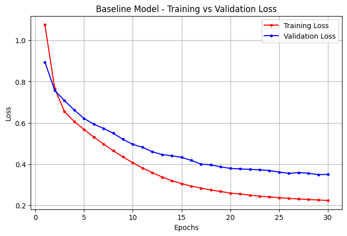

```python
plot_loss(baseline_history, plot_title="Baseline Model - Training vs Validation Loss")
```

The graph above shows that both training loss and validation loss start relatively high, confirming that the model is initially learning and adjusting its parameters. As training progresses, both losses continue to decrease, indicating effective learning. The gap between training and validation loss remains small, suggesting that the model is generalizing well without significant overfitting in the early stages. However, later in training, the training loss continues to decrease, while the validation loss begins to plateau, meaning additional training may not improve generalization on unseen data.

Overall, the model is improving, and there is no clear overfitting yet, but the increasing gap between training and validation loss might indicate the early signs of mild overfitting. At this stage, fine-tuning strategies such as early stopping or regularization may be beneficial to prevent overfitting and improve the model’s ability to generalize.

## 7. Developing a Model that Overfits

Next, we will develop a deliberately overfitting model to better understand its capacity and refine hyperparameters. This process helps us identify the model's limits, optimize its architecture, and improve generalization. The ideal model exists at the balance point between underfitting and overfitting, meaning it learns effectively without memorizing the training data. To achieve this balance, we must first explore the extremes, allowing the model to overfit before applying techniques to bring it back to the optimal middle ground. We can start by increasing model complexity by adding another hidden layer to our model to make it a bit more complex. and use a larger number of neurons like 32 and train for more epochs like a 100 epochs

```python
# Define an overfitting model
overfitting_model = Sequential([
    Input(shape=(X_train.shape[1],)),
    Dense(32, activation='relu'),  # Add another hidden layer
    Dense(16, activation='relu'),
    Dense(3, activation='softmax')
])

# Compile the model
compile_model(overfitting_model)

# Train the model
overfitting_history = train_model(overfitting_model, X_train, y_train, X_val, y_val, epochs=100, class_weight=class_weight_dict)

# Evaluate the model
overfitting_results = evaluate_model(overfitting_model, X_val, y_val)

# Get class predictions
y_pred, y_true = get_predictions(overfitting_model, X_val, y_val)

# Compute Balanced Accuracy
balanced_acc = balanced_accuracy_score(y_true, y_pred)

# Print evaluation results
print("Overfitting Model")
print_evaluation_results(balanced_acc, overfitting_results[1], overfitting_results[2], overfitting_results[3], y_pred)
```

```
Overfitting Model
Balanced Accuracy: 0.78
Precision: 0.90
Recall: 0.88
F1 Score (Macro): 0.78
Prediction Distribution: {0: 141, 1: 11, 2: 18}
```

The overfitting model achieves a balanced accuracy of 0.78 significantly higher than the baseline model which indicates that the model is performing well in terms of recognizing underrepresented class despite its overfitting tendencies. It also achieves a higher precision of 0.90 than that of the baseline model meaning its more accurate when it predicts the positive class. This model also has a higher recall of 0.88 compared to the baseline model that indicates that it is correctly identifying more instances of the actual positive class than the baseline model.

Despite the high metric values, it is important to analyze the validation and training loss to determine whether the model is truly learning and generalizing, rather than simply memorizing the training data. Below is the training vs. validation loss plot, which allows us to observe the progression of losses over time.

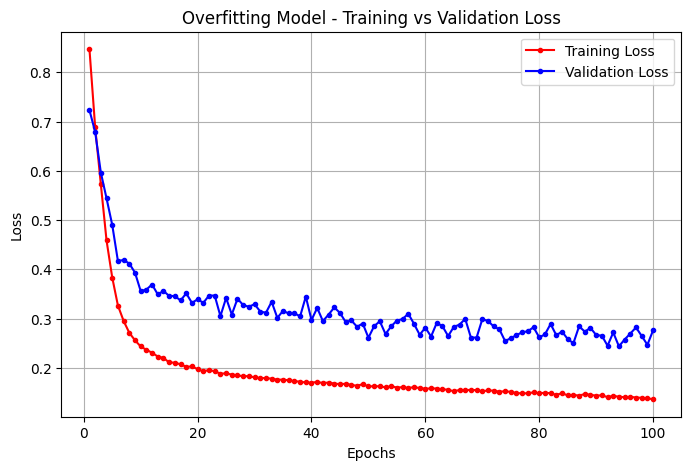

```python
plot_loss(overfitting_history, plot_title="Overfitting Model - Training vs Validation Loss")
```

The graph clearly shows an overfitting model, the training loss keeps on decreasing meaning that it is continuing to improve on the training data or memorizing patterns. Additionally, the validation loss stops decreasing quite early on and started to fluctuate or become noisy signifying that the model is no longer learning general patterns and is overfitting instead.

The fluctuations suggest instability, meaning the model struggles to generalize. There is also a clear larger growing gap compared to the baseline model in between the training and validation loss which is one of the signs of overfitting. This means that we have achieved our goal in developing an overfitting model and we can start fine-tuning the model to improve generalization

## 8. Finalizing the Model Architecture

Before applying regularization and fine-tuning the overfitting model, it is essential to first establish a stable and well-defined model architecture. In this section, we will determine the optimal model structure and select the appropriate number of hidden neurons to ensure effective learning.

### 8.1 Network Architecture

In our current setup, the baseline model uses a single hidden layer with 16 neurons. This model performs adequately but does not reach optimal performance. On the other hand, our overfitting model uses two hidden layers and performs well on the training data, but it suffers from overfitting, indicating that the model has too much capacity for the data. To compare these two architectures, we will use Stratified K-Fold Cross-Validation to evaluate both the single hidden layer model and the two hidden layer model. This will allow us to compute and compare several key metrics (balanced accuracy, precision, recall, and F1 score) to determine which architecture performs better.

The first step in this process is to define a function that creates the model with either a single hidden layer or two hidden layers, depending on the architecture we want to test. For the single hidden layer model, we will use 16 neurons, while for the two hidden layer model, we will use 32 neurons in the first hidden layer and 16 neurons in the second hidden layer.

```python
# Define 5-Fold Cross-Validation
kfold = StratifiedKFold(n_splits=5, shuffle=True, random_state=42)

# Function to Create Models
def create_model(num_hidden_layers=1):
    model = Sequential([
        Input(shape=(X_train.shape[1],)),  # Input layer (21 features)
    ])

    # Add one or two hidden layers based on the parameter
    if num_hidden_layers == 1:
        model.add(Dense(16, activation='relu'))
    else:
        model.add(Dense(32, activation='relu'))
        model.add(Dense(16, activation='relu'))

    model.add(Dense(3, activation='softmax'))  # Output layer for 3 classes

    return model
```

Once the model architecture is defined, we will run Stratified K-Fold Cross-Validation to evaluate both models. Stratified K-Fold ensures that the class distribution is preserved in each fold, which is important when working with imbalanced datasets. We will compute the performance metrics for each fold, and then average the results to identify which model architecture is more effective. This process will help us compare the performance of a single hidden layer model against a two hidden layer model to determine which configuration best suits our dataset.

```python
# Store metrics across all folds for both models
results_1_layer = {'balanced_acc': [], 'precision': [], 'recall': [], 'f1_score': []}
results_2_layers = {'balanced_acc': [], 'precision': [], 'recall': [], 'f1_score': []}

# Perform K-Fold Cross-Validation
for train_idx, val_idx in kfold.split(X_train, y_train.argmax(axis=1)):
    X_train_fold, X_val_fold = X_train[train_idx], X_train[val_idx]
    y_train_fold, y_val_fold = y_train[train_idx], y_train[val_idx]

    # Train and Evaluate 1 Hidden Layer Model
    model_1 = create_model(num_hidden_layers=1)
    compile_model(model_1)
    model_1_history = train_model(model_1, X_train_fold, y_train_fold, X_val_fold, y_val_fold, epochs=100, class_weight=class_weight_dict)
    model_1_results = evaluate_model(model_1, X_val_fold, y_val_fold)
    y_pred_1, y_true_1 = get_predictions(model_1, X_val_fold, y_val_fold)
    balanced_acc_1 = balanced_accuracy_score(y_true_1, y_pred_1)

    # Store the metrics for 1 hidden layer model
    results_1_layer['balanced_acc'].append(balanced_acc_1)
    results_1_layer['precision'].append(model_1_results[1])  # Precision
    results_1_layer['recall'].append(model_1_results[2])  # Recall
    results_1_layer['f1_score'].append(model_1_results[3])  # F1-Score

    # Train and Evaluate 2 Hidden Layer Model
    model_2 = create_model(num_hidden_layers=2)
    compile_model(model_2)
    model_2_history = train_model(model_2, X_train_fold, y_train_fold, X_val_fold, y_val_fold, epochs=100, class_weight=class_weight_dict)
    model_2_results = evaluate_model(model_2, X_val_fold, y_val_fold)
    y_pred_2, y_true_2 = get_predictions(model_2, X_val_fold, y_val_fold)
    balanced_acc_2 = balanced_accuracy_score(y_true_2, y_pred_2)

    # Store the metrics for 2 hidden layer model
    results_2_layers['balanced_acc'].append(balanced_acc_2)
    results_2_layers['precision'].append(model_2_results[1])  # Precision
    results_2_layers['recall'].append(model_2_results[2])  # Recall
    results_2_layers['f1_score'].append(model_2_results[3])  # F1-Score

# Compute Averages for each metric after cross-validation
avg_results_1_layer = {key: np.mean(val) for key, val in results_1_layer.items()}
avg_results_2_layers = {key: np.mean(val) for key, val in results_2_layers.items()}

# Print the average results for both models
print("\n1 Hidden Layer Model (Average over K-Folds)")
print(f"Avg Balanced Accuracy: {avg_results_1_layer['balanced_acc']:.2f}")
print(f"Avg Precision: {avg_results_1_layer['precision']:.2f}")
print(f"Avg Recall: {avg_results_1_layer['recall']:.2f}")
print(f"Avg F1 Score: {avg_results_1_layer['f1_score']:.2f}")

print("\n2 Hidden Layer Model (Average over K-Folds)")
print(f"Avg Balanced Accuracy: {avg_results_2_layers['balanced_acc']:.2f}")
print(f"Avg Precision: {avg_results_2_layers['precision']:.2f}")
print(f"Avg Recall: {avg_results_2_layers['recall']:.2f}")
print(f"Avg F1 Score: {avg_results_2_layers['f1_score']:.2f}")
```

```
1 Hidden Layer Model (Average over K-Folds)
Avg Balanced Accuracy: 0.69
Avg Precision: 0.88
Avg Recall: 0.85
Avg F1 Score: 0.66

2 Hidden Layer Model (Average over K-Folds)
Avg Balanced Accuracy: 0.73
Avg Precision: 0.88
Avg Recall: 0.86
Avg F1 Score: 0.71
```

Based on the results averaged over 5 folds of Stratified K-Fold Cross-Validation, we can conclude that the two layer model performs better than the single layer model. The balanced accuracy of the two layer model is 0.73, compared to 0.69 for the single layer model. This suggests that the two layer model is more effective at handling class imbalance, as it maintains more consistent accuracy across all classes. Both models demonstrate high precision and recall. However, the two layer model performs slightly better, with a recall of 0.86, compared to 0.85 for the single layer model.

### 8.2 Number of Hidden Neurons

Once the model architecture is finalized, the next step is to tune the number of hidden neurons. The number of neurons in each hidden layer plays a crucial role in the model’s ability to learn from the data. Too few neurons can lead to underfitting, while too many can result in overfitting.

```python
# Function to Create Models
def create_model(neurons_1=32, neurons_2=16):
    model = Sequential([
        Input(shape=(X_train.shape[1],)),  # Input layer (number of features)
        Dense(neurons_1, activation='relu'),
        Dense(neurons_2, activation='relu'),
        Dense(3, activation='softmax')  # Output layer for 3 classes
    ])

    return model
```

After updating the model, we will run Stratified K-Fold Cross-Validation to evaluate each configuration. We will iterate this process three times, testing the model’s performance on each configuration and comparing metrics such as balanced accuracy, precision, and recall. This will allow us to assess how well the model generalizes across the data and help us select the best-performing configuration for further tuning.

```python
# Store results for different neuron configurations
neuron_configs = {"16→8": {'balanced_acc': [], 'precision': [], 'recall': [], 'f1_score': []},
                  "32→16": {'balanced_acc': [], 'precision': [], 'recall': [], 'f1_score': []},
                  "8→4": {'balanced_acc': [], 'precision': [], 'recall': [], 'f1_score': []}}

# Perform K-Fold Cross-Validation for different neuron configurations
for config in neuron_configs:
    neurons_1, neurons_2 = map(int, config.split('→'))

    for train_idx, val_idx in kfold.split(X_train, y_train.argmax(axis=1)):
        X_train_fold, X_val_fold = X_train[train_idx], X_train[val_idx]
        y_train_fold, y_val_fold = y_train[train_idx], y_train[val_idx]

        # Create the model with the current configuration
        model = create_model(neurons_1=neurons_1, neurons_2=neurons_2)
        compile_model(model)

        # Train the model
        model_history = train_model(model, X_train_fold, y_train_fold, X_val_fold, y_val_fold, epochs=100, class_weight=class_weight_dict)

        # Evaluate the model
        model_results = evaluate_model(model, X_val_fold, y_val_fold)

        # Get Predictions and Compute Balanced Accuracy
        y_pred, y_true = get_predictions(model, X_val_fold, y_val_fold)
        balanced_acc = balanced_accuracy_score(y_true, y_pred)

        # Store Metrics for the current configuration
        neuron_configs[config]['balanced_acc'].append(balanced_acc)
        neuron_configs[config]['precision'].append(model_results[1])  # Precision
        neuron_configs[config]['recall'].append(model_results[2])  # Recall
        neuron_configs[config]['f1_score'].append(model_results[3])  # F1-Score

# Compute Averages for each configuration after cross-validation
for config in neuron_configs:
    avg_results = {key: np.mean(val) for key, val in neuron_configs[config].items()}

    # Print the average results for each model configuration
    print(f"\n{config} Model (Average over K-Folds)")
    print(f"Avg Balanced Accuracy: {avg_results['balanced_acc']:.2f}")
    print(f"Avg Precision: {avg_results['precision']:.2f}")
    print(f"Avg Recall: {avg_results['recall']:.2f}")
    print(f"Avg F1 Score: {avg_results['f1_score']:.2f}")
```

```
16→8 Model (Average over K-Folds)
Avg Balanced Accuracy: 0.70
Avg Precision: 0.89
Avg Recall: 0.85
Avg F1 Score: 0.67

32→16 Model (Average over K-Folds)
Avg Balanced Accuracy: 0.74
Avg Precision: 0.88
Avg Recall: 0.86
Avg F1 Score: 0.72

8→4 Model (Average over K-Folds)
Avg Balanced Accuracy: 0.68
Avg Precision: 0.88
Avg Recall: 0.83
Avg F1 Score: 0.62
```

### 8.3 Summary

Although our finalized model shares the same structure as the overfitting model, this does not mean that it is immune to overfitting. While we have established the model architecture, further steps are needed to ensure that it generalizes well to unseen data. The current goal is to determine the optimal model architecture, one that provides a balance between learning capacity and generalization. By testing different configurations, we aim to identify the architecture that performs best across various metrics while minimizing overfitting, ensuring the model is capable of handling both the training data and unseen data effectively.

## 9. Regularization and Hyperparameters Tuning

In this section, we will explore techniques of regularization and hyperparameter tuning to enhance the model’s generalization and performance, while also prevent overfitting. This step is crucial to ensure that the model not only fits the training data well but also generalizes effectively to unseen data. Here, we will be using stratified k-fold cross validation to find out the optimal value for each hyperparameters. So before we begin, we need to update and solidify our "create_model()" function and create a "run_kfold()" function to facilitate easier cross-validation.

```python
# Function to Create Models
def create_model(input_shape, dropout_rate=None, l2_value=None):
    model = Sequential()

    # Input layer
    model.add(Input(shape=(input_shape,)))

    # First hidden layer
    model.add(Dense(32, activation='relu', kernel_regularizer=l2(l2_value) if l2_value else None))
    if dropout_rate:
        model.add(Dropout(dropout_rate))  # Apply dropout if specified

    # Second hidden layer
    model.add(Dense(16, activation='relu', kernel_regularizer=l2(l2_value) if l2_value else None))
    if dropout_rate:
        model.add(Dropout(dropout_rate))  # Apply dropout if specified

    # Output layer for 3 classes
    model.add(Dense(3, activation='softmax'))

    return model

def run_kfold(neurons_1=32, neurons_2=16, dropout_rate=0.1, l2_value=0.001, learning_rate=0.001, optimizer_name="rmsprop", batch_size=32, epochs=30):
    fold_results = {'balanced_acc': [], 'precision': [], 'recall': [], 'f1_score': []}

    for train_idx, val_idx in kfold.split(X_train, y_train.argmax(axis=1)):
        X_train_fold, X_val_fold = np.array(X_train[train_idx]), np.array(X_train[val_idx])
        y_train_fold, y_val_fold = np.array(y_train[train_idx]), np.array(y_train[val_idx])

        # Create the model
        model = create_model(X_train.shape[1], dropout_rate=dropout_rate, l2_value=l2_value)

        # Compile the model
        compile_model(model, learning_rate=learning_rate, optimizer_name=optimizer_name)

        # Train the model
        model_history = train_model(model, X_train_fold, y_train_fold, X_val_fold, y_val_fold, epochs=epochs, batch_size=batch_size)

        # Evaluate the model
        model_results = evaluate_model(model, X_val_fold, y_val_fold)

        # Get Predictions and Compute Balanced Accuracy
        y_pred, y_true = get_predictions(model, X_val_fold, y_val_fold)
        balanced_acc = balanced_accuracy_score(y_true, y_pred)

        # Store Metrics
        fold_results['balanced_acc'].append(balanced_acc)
        fold_results['precision'].append(model_results[1])  # Precision
        fold_results['recall'].append(model_results[2])  # Recall
        fold_results['f1_score'].append(model_results[3])  # F1-Score

    # Compute Averages
    return {key: np.mean(val) for key, val in fold_results.items()}
```

### 9.1 Regularization

Regularization refers to a set of techniques used to prevent overfitting and improve a model’s ability to generalize to new data. It involves adding a penalty term to the loss function during training, which discourages the model from becoming too complex or having excessively large parameter values. This helps control the model’s tendency to fit noise in the training data. In this study, we will examine two forms of regularization: dropout and L2 regularization, both of which help enhance the model’s robustness and performance on unseen data.

#### 9.1.1 L2 Regularization

L1 and L2 regularization are techniques used to penalize large weights in a model to prevent overfitting and improve generalization. They achieve this by adding a penalty term to the loss function, which helps constrain the model’s capacity and prevents it from becoming too complex.

In this task, we will use L2 regularization, as it is the most commonly applied method and serves as a strong default choice for preventing overfitting. To determine the optimal L2 value, we will perform cross-validation across multiple values to identify the best-performing regularization strength.

```python
# K-Fold for Different Regularization Values
for l2_value in [0.0001, 0.001, 0.01, 0.1]:
    results = run_kfold(l2_value=l2_value)
    print(f"\nL2 Regularization: {l2_value}")
    print(f"Avg Balanced Accuracy: {results['balanced_acc']:.2f}")
    print(f"Avg Precision: {results['precision']:.2f}")
    print(f"Avg Recall: {results['recall']:.2f}")
    print(f"Avg F1 Score: {results['f1_score']:.2f}")
```

```
L2 Regularization: 0.0001
Avg Balanced Accuracy: 0.75
Avg Precision: 0.90
Avg Recall: 0.88
Avg F1 Score: 0.78

L2 Regularization: 0.001
Avg Balanced Accuracy: 0.77
Avg Precision: 0.90
Avg Recall: 0.88
Avg F1 Score: 0.79

L2 Regularization: 0.01
Avg Balanced Accuracy: 0.68
Avg Precision: 0.89
Avg Recall: 0.84
Avg F1 Score: 0.72

L2 Regularization: 0.1
Avg Balanced Accuracy: 0.33
Avg Precision: 0.78
Avg Recall: 0.78
Avg F1 Score: 0.29
```

According to the result above, the L2 Regularization of 0.001 gives the best performance with the highest average balanced accuracy of 0.77, a strong precision of 0.90 and recall of 0.88 and achieved the best f1 score of 0.79 that signals there’s a good balance between precision and recall. The results also show that if L2 regularization increases beyond 0.001, the model’s performance will deteriorate which can be seen from the decrease in recall and F1 score

#### 9.1.2 Dropout

Dropout is a regularization technique that helps prevent overfitting by randomly deactivating a fraction of neurons during training. This forces the model to rely on multiple independent neurons, preventing co-adaptation where neurons become overly dependent on each other and making the model more robust. During training, a specified percentage of neurons are randomly dropped, while during testing, all neurons are used, but their outputs are scaled to compensate. Dropout encourages the model to learn more generalizable features, improving its performance on unseen data.

```python
# K-Fold for Different Dropout Rates
for dropout_rate in [0.1, 0.2, 0.3, 0.4, 0.5]:
    results = run_kfold(dropout_rate=dropout_rate)
    print(f"\nDropout: {dropout_rate}")
    print(f"Avg Balanced Accuracy: {results['balanced_acc']:.2f}")
    print(f"Avg Precision: {results['precision']:.2f}")
    print(f"Avg Recall: {results['recall']:.2f}")
    print(f"Avg F1 Score: {results['f1_score']:.2f}")
```

```
Dropout: 0.1
Avg Balanced Accuracy: 0.78
Avg Precision: 0.90
Avg Recall: 0.87
Avg F1 Score: 0.79

Dropout: 0.2
Avg Balanced Accuracy: 0.74
Avg Precision: 0.90
Avg Recall: 0.86
Avg F1 Score: 0.76

Dropout: 0.3
Avg Balanced Accuracy: 0.74
Avg Precision: 0.90
Avg Recall: 0.85
Avg F1 Score: 0.77

Dropout: 0.4
Avg Balanced Accuracy: 0.70
Avg Precision: 0.91
Avg Recall: 0.82
Avg F1 Score: 0.73

Dropout: 0.5
Avg Balanced Accuracy: 0.66
Avg Precision: 0.91
Avg Recall: 0.80
Avg F1 Score: 0.70
```

Across five different dropout values, we observe that a dropout rate of 0.1 achieves the highest balanced accuracy of 0.78 and F1 score of 0.79. This suggests that a small amount of dropout helps prevent overfitting while maintaining strong generalization. Additionally, as dropout increases, performance gradually declines, indicating that higher dropout rates may lead to underfitting, reducing the model's ability to effectively learn and generalize.

### 9.2 Hyperparameter Tuning

Hyperparameter tuning is the process of selecting the optimal values for a model’s hyperparameters, which are settings that control the learning process. These include parameters such as the learning rate, number of neurons, batch size, and optimizer used by the model. The goal of hyperparameter tuning is to identify the values that lead to the best performance by improving generalization and minimizing overfitting.

For this study, we will tune learning rates, optimizers, batch size, and epochs, while using stratified K-fold cross validation to ensure that the selected hyperparameters are optimized and provide consistent performance across different data splits.

#### 9.2.1 Learning rate

The learning rate is a critical hyperparameter that controls how much to change the model in response to the estimated error each time the model weights are updated. A too high learning rate may result in an unstable training process while a too low learning rate can result in a long training process that could get stuck

```python
# K-Fold for Different Learning Rates
for learning_rate in [1e-5, 1e-4, 1e-3, 1e-2]:
    results = run_kfold(learning_rate=learning_rate)
    print(f"\nLearning Rate: {learning_rate}")
    print(f"Avg Balanced Accuracy: {results['balanced_acc']:.2f}")
    print(f"Avg Precision: {results['precision']:.2f}")
    print(f"Avg Recall: {results['recall']:.2f}")
    print(f"Avg F1 Score: {results['f1_score']:.2f}")
```

```
Learning Rate: 1e-05
Avg Balanced Accuracy: 0.35
Avg Precision: 0.55
Avg Recall: 0.10
Avg F1 Score: 0.32

Learning Rate: 0.0001
Avg Balanced Accuracy: 0.33
Avg Precision: 0.79
Avg Recall: 0.78
Avg F1 Score: 0.30

Learning Rate: 0.001
Avg Balanced Accuracy: 0.76
Avg Precision: 0.90
Avg Recall: 0.87
Avg F1 Score: 0.78

Learning Rate: 0.01
Avg Balanced Accuracy: 0.74
Avg Precision: 0.89
Avg Recall: 0.89
Avg F1 Score: 0.78
```

Across the four different learning rate values, the learning rate of 0.001 achieved the highest balanced accuracy of 0.76 and precision with 0.90, indicating optimal performance. From this, we learn that very small learning rates lead to poor performance, as they cause the model to converge too slowly or get stuck, preventing effective learning and generalization.

#### 9.2.2 Optimizer

So far, we have been using RMSprop as our optimizer to adjust the parameters of our machine learning model. However, it is important to experiment with different optimizers, as each optimizer has unique convergence properties. By testing multiple optimizers, we can identify the one that best suits our model and dataset, leading to faster convergence, better stability, and improved performance. In this section, we will test two other optimizers, Adam and SGD, to determine which one performs best for this model.

```python
# K-Fold for Different Optimizers
for optimizer in ["adam", "rmsprop", "sgd"]:
    results = run_kfold(optimizer_name=optimizer)
    print(f"\nOptimizer: {optimizer.upper()}")
    print(f"Avg Balanced Accuracy: {results['balanced_acc']:.2f}")
    print(f"Avg Precision: {results['precision']:.2f}")
    print(f"Avg Recall: {results['recall']:.2f}")
    print(f"Avg F1 Score: {results['f1_score']:.2f}")
```

```
Optimizer: ADAM
Avg Balanced Accuracy: 0.76
Avg Precision: 0.90
Avg Recall: 0.88
Avg F1 Score: 0.79

Optimizer: RMSPROP
Avg Balanced Accuracy: 0.75
Avg Precision: 0.90
Avg Recall: 0.86
Avg F1 Score: 0.77

Optimizer: SGD
Avg Balanced Accuracy: 0.33
Avg Precision: 0.78
Avg Recall: 0.78
Avg F1 Score: 0.29
```

From the results above, the Adam optimizer achieves the best overall performance, with a balanced accuracy of 0.76, high precision, high recall, and the best F1 score. In contrast, SGD performs the worst, with a very low balanced accuracy of 0.33, meaning the model is performing no better than random guessing. Additionally, its poor F1 score confirms that SGD fails to balance precision and recall. In conclusion, Adam is the best optimizer for this task.

#### 9.2.3 Batch Size

Like the optimizer, so far we have been using a fixed batch size during training, but it is essential to experiment with different batch sizes. The batch size affects the model’s learning dynamics, including convergence speed and stability. Smaller batch sizes may result in noisier updates but could help the model generalize better, while larger batch sizes offer more stable updates but could lead to slower convergence. By testing different batch sizes, we aim to identify the one that provides the best balance between training efficiency and model performance.

```python
# K-Fold for Different Batch Sizes
for batch_size in [16, 32, 64]:
    results = run_kfold(batch_size=batch_size)
    print(f"\nBatch Size: {batch_size}")
    print(f"Avg Balanced Accuracy: {results['balanced_acc']:.2f}")
    print(f"Avg Precision: {results['precision']:.2f}")
    print(f"Avg Recall: {results['recall']:.2f}")
    print(f"Avg F1 Score: {results['f1_score']:.2f}")
```

```
Batch Size: 16
Avg Balanced Accuracy: 0.79
Avg Precision: 0.90
Avg Recall: 0.88
Avg F1 Score: 0.80

Batch Size: 32
Avg Balanced Accuracy: 0.77
Avg Precision: 0.90
Avg Recall: 0.87
Avg F1 Score: 0.79

Batch Size: 64
Avg Balanced Accuracy: 0.71
Avg Precision: 0.90
Avg Recall: 0.86
Avg F1 Score: 0.75
```

From the cross validation results, we observe that a batch size of 16 achieves the highest balanced accuracy with 0.79 and F1 score of 0.80, along with high precision and recall. This indicates that a batch size of 16 provides the best balance between learning efficiency and generalization. Therefore, we conclude that a batch size of 16 is the optimal choice for this model.

#### 9.2.4 Epochs

For epochs, we will use early stopping instead of manually determining the optimal value. Early stopping automatically halts training once the model's performance on the validation set stops improving, preventing unnecessary training and reducing computational cost and time consumption.

Additionally, early stopping helps prevent overfitting by ensuring the model does not continue learning patterns specific to the training data that do not generalize well to unseen data. However, we will set the maximum number of epochs to 100, allowing the model to train for up to 100 epochs unless early stopping triggers an earlier stop.

```python
early_stopping = EarlyStopping(monitor="val_loss", patience=10, restore_best_weights=True)
```

#### 9.2.5 Summary

To summarize the extensive process of regularization and hyperparameter tuning, we have utilized Stratified K-Fold Cross-Validation to identify the optimal values for the key parameters. For regularization, the best value for L2 regularization is 0.001, and the optimal dropout rate is 0.1. Regarding hyperparameters, the ideal learning rate is 0.001, the best optimizer is Adam, and the optimal batch size is 16. For epochs, we will set the maximum number of 100 epochs and implement early stopping, which will automatically halt training when the model's performance no longer improves. With these carefully tuned parameter values, we are now ready to move forward and build the final model.1

## 10. Evaluation

In this section, we will leverage the optimal hyperparameters identified through our extensive tuning and validation process to construct the final model. This model will be trained on the full dataset, which includes both the training and validation sets, ensuring that it learns from the maximum amount of data available.

Once training is complete, we will evaluate the model on the test set, which has remained unseen throughout the entire process. This evaluation will provide a true measure of the model’s generalization ability, allowing us to assess its performance on new, real-world data.

### 10.1 Final Model Creation

First, we begin by creating our final model using our custom function, "create_model". This model consists of 2 layers with 32 neurons in the first hidden layer and 16 neurons in the second hidden layer, a structure determined through Stratified K-Fold cross validation. Additionally, it includes a 0.1 dropout layer and an L2 regularization value of 0.001 to enhance generalization and prevent overfitting.

```python
# Create the final model
final_model = create_model(X_train.shape[1], dropout_rate=0.1, l2_value=0.001)
```

### 10.2 Final Model Compilation

Next, we proceed with compiling the final model, using a learning rate of 0.001 and the Adam optimizer, which was selected based on the hyperparameter tuning process. This ensures efficient weight updates and stable convergence during training.

```python
# Compile the final model
compile_model(final_model, learning_rate=0.001, optimizer_name="adam")
```

### 10.3 Final Model Training

Before proceeding with training, we combine the training and validation datasets to ensure the model learns from the maximum amount of available data before testing. This is done using the "np.concatenate" function from NumPy, which merges the datasets efficiently. Since we have already fine-tuned the hyperparameters, the validation set is no longer needed separately for tuning. Instead, we train the final model using all available training data and reserve the test set for the final evaluation.

For training, we will use a batch size of 16, selected through hyperparameter tuning, and train for a maximum of 100 epochs while implementing early stopping to prevent overfitting. Additionally, we apply class weights to handle class imbalances and use a validation split of 20% within the combined dataset to monitor performance during training. This setup ensures that the model fully leverages available data while maintaining effective regularization and monitoring strategies

```python
# Combine training and validation set
X_full_train = np.concatenate((X_train, X_val), axis=0)
y_full_train = np.concatenate((y_train, y_val), axis=0)

# Train the model
final_model_history = final_model.fit(
    X_full_train, y_full_train,
    epochs=100,
    batch_size=16,
    class_weight=class_weight_dict,
    validation_split=0.2,
    verbose=0,
    callbacks=[early_stopping]
)
```

### 10.4 Final Model Evaluation

After training, we will evaluate the model on the test set, which has been set aside and remained unused during training to ensure no data leakage. This guarantees that the model is assessed on completely unseen data, providing an accurate measure of its generalization ability. Evaluating on an independent test set helps confirm that the model is not simply memorizing patterns from the training data but can effectively make predictions on new, real-world data.

```python
# Evaluate on the Test Set (Final Evaluation)
final_model_results = final_model.evaluate(X_test, y_test, batch_size=16, verbose=0)

# Get class predictions
y_pred, y_true = get_predictions(final_model, X_test, y_test)
```

### 10.5 Final Model Analysis

In this section, we will analyze the evaluation results of our final model, plot the training loss vs. validation loss graph, compute the confusion matrix, and compare the evaluation metrics with previous models to assess overall performance and improvements.

```python
# Compute Balanced Accuracy
balanced_acc = balanced_accuracy_score(y_true, y_pred)

# Print evaluation results
print("Final Model Evaluation")
print_evaluation_results(balanced_acc, final_results[1], final_results[2], final_results[3], y_pred)
```

```
Final Model Evaluation
Balanced Accuracy: 0.73
Precision: 0.89
Recall: 0.86
F1 Score (Macro): 0.72
Prediction Distribution: {0: 357, 1: 26, 2: 43}
```

As seen from the results above, the final model's performance is slightly lower than expected. The balanced accuracy of 0.73 falls below the 80% target, but the model still performs well overall. It achieves a strong precision of 0.89 and a high recall of 0.86, both exceeding 80%, indicating that the model makes accurate predictions while capturing most positive cases.

However, the macro F1 score is 0.72, which is below the intended goal of 0.75%. Additionally, the F1 score is lower than both precision and recall, suggesting an imbalance between the two metrics, likely due to class imbalance still affecting the model's performance.

When comparing to previous models (as shown in the table below), we observe that the final model outperforms the baseline model, showing significant improvements in balanced accuracy (from 0.68 to 0.73) and F1 score (from 0.63 to 0.72). However, its results are slightly lower than the overfitting model, which is expected. This is actually a positive outcome, as the overfitting model had higher performance but lacked generalization, whereas the final model achieves a better balance between accuracy and generalization.

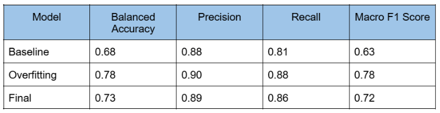

Next, we will analyze the training loss vs. validation loss graph to further examine the model's learning behavior.

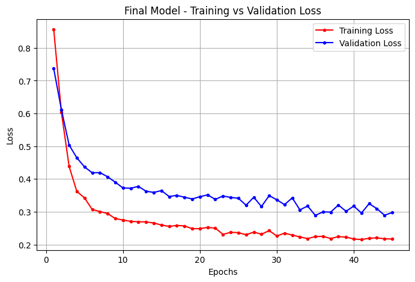

```python
plot_loss(final_model_history, plot_title="Final Model - Training vs Validation Loss")
```

From the graph above, we can see that during the first few epochs (0–10), both training and validation loss decrease sharply, indicating that the model is quickly learning key patterns in the data. After epoch 10–15, the training loss continues to improve steadily, suggesting that the model is still learning from the training data.

The validation loss does not show major spikes or sharp increases, meaning there is no severe overfitting. However, the fluctuations in validation loss suggest that the model could still benefit from additional regularization to further stabilize performance.

Next, we can plot a confusion matrix to visualize the actual predictions made by our final model and analyze how well it classifies each class.

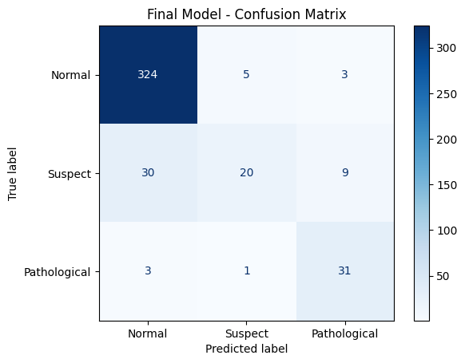

```python
# Get true labels and predictions
y_pred_classes = y_pred.argmax(axis=1)  # Convert probabilities to class labels

# Generate Confusion Matrix
cm = confusion_matrix(y_true, y_pred_classes)

# Display Confusion Matrix
disp = ConfusionMatrixDisplay(confusion_matrix=cm, display_labels=["Normal", "Suspect", "Pathological"])
disp.plot(cmap="Blues")
plt.title("Final Model - Confusion Matrix")
plt.show()
```

The confusion matrix above reveals that the final model performs well in classifying "Normal" cases, correctly predicting 324 instances, with only a few misclassifications as Suspect (5) and Pathological (3). However, the model struggles with "Suspect" cases, as 30 were misclassified as Normal and 9 as Pathological, indicating difficulty in distinguishing intermediate-risk cases. The model performs reasonably well in detecting "Pathological" cases, correctly classifying 31 instances, though 3 were misclassified as "Normal", which could be critical in a medical setting. These results highlight that the issue of class imbalance is still present, affecting the model's ability to correctly classify minority classes, particularly the "Suspect" category.

## 11. Conclusion

In this project, we successfully developed and optimized a deep learning model for fetal health classification, utilizing Stratified K-Fold Cross-Validation, regularization, and hyperparameter tuning to refine the model’s generalization ability. The final model achieved a balanced accuracy of 0.73, precision of 0.89, recall of 0.86, and an F1 score of 0.72, demonstrating a significant improvement over the baseline model while mitigating some of the overfitting seen in earlier models. These improvements confirm that our tuning and optimization strategies effectively enhanced classification performance, particularly in distinguishing Normal and Pathological cases.

Despite these advances, the model still exhibited some overfitting, especially in classifying Suspect cases, which remained the most challenging category. The confusion matrix revealed that many Suspect cases were misclassified as Normal, suggesting that the model struggles to differentiate between borderline fetal health conditions. This issue is likely due to the small dataset size and class imbalance, where the model learns patterns from the majority class (Normal) more effectively than from the minority classes (Suspect and Pathological). Expanding the dataset with more diverse and representative samples could help improve the model's ability to recognize more subtle differences between classes.

Another challenge was the fluctuations in validation loss, indicating that while the model was able to generalize better than the overfitting model, there was still room for improvement. Additional regularization techniques, such as stronger dropout strategies, hybrid L1-L2 regularization, or advanced learning rate decay schedules, could help stabilize training further. The model's ability to detect Pathological cases was fairly strong, but there were still some critical misclassifications, which could have real-world consequences in medical settings. A greater focus on recall for high-risk cases could help ensure that fewer critical conditions are missed.

One major limitation of this study was the small dataset size, which restricted the model’s ability to fully generalize. Deep learning models typically require large amounts of training data, and with only 2,126 records, the dataset was relatively limited. A larger dataset would likely improve model performance and reduce sensitivity to noise in the data. Furthermore, the class imbalance issue negatively impacted the model’s ability to correctly classify Suspect cases, as the model was biased toward predicting the dominant class. Addressing this imbalance through class-weighting, resampling techniques like SMOTE, or data augmentation could help improve classification performance across all classes.

Despite these challenges, this project demonstrated that carefully tuning hyperparameters, applying regularization, and optimizing training strategies can significantly improve fetal health classification models. While this study was limited to fully connected neural networks, future work could explore more advanced architectures, such as CNNs for feature extraction from CTG signals, RNNs or LSTMs for handling temporal dependencies in fetal monitoring data, or transformer-based models for more robust feature learning. Implementing ensemble learning techniques could also improve the model’s overall robustness and reduce misclassifications.

Future improvements could also focus on incorporating additional real-world clinical data, which would provide a more diverse dataset for training. This could help improve the model’s reliability in detecting less common but high-risk fetal conditions. By improving the dataset and fine-tuning model architecture, this approach has the potential to be applied in clinical decision support systems, aiding healthcare professionals in identifying fetal distress and improving maternal and neonatal health outcomes.

Overall, our final model successfully improved upon the baseline model while avoiding the excessive overfitting seen in the overfitting model. While the challenge of correctly classifying Suspect cases remains, the study provides a strong foundation for further refinements. With enhancements in data balancing, architectural improvements, and additional regularization techniques, this model could become an even more powerful tool for fetal health assessment, contributing to more accurate and timely diagnoses in real-world clinical settings.

## 12. References

1. Chollet, F. (2017) *Deep Learning with Python*, 1st edn. Sebastopol, CA: Manning Publications. Available at: https://www.manning.com/books/deep-learning-with-python (Accessed: 15 February 2025).
2. Mvd, A. (2020) ‘Fetal Health Classification Dataset’, *Kaggle*. Available at: https://www.kaggle.com/datasets/andrewmvd/fetal-health-classification (Accessed: 15 February 2025).
3. Ayres-de-Campos, D., Bernardes, J., Garrido, A., Marques-de-Sá, J. and Pereira-Leite, L. (2000) ‘Cardiotocography Data Set’, *UCI Machine Learning Repository*. Available at: https://archive.ics.uci.edu/ml/datasets/cardiotocography (Accessed: 15 February 2025).
4. Ayres de Campos, D., Bernardes, J., Garrido, A., Marques-de-Sá, J. and Pereira-Leite, L. (2000) ‘SisPorto 2.0: A program for automated analysis of cardiotocograms’, *Journal of Maternal-Fetal Medicine*, 9(5), pp. 311–318. Available at: https://doi.org/10.1002/1520-6661(200009/10)9:5<311::AID-MFM12>3.0.CO;2-9 (Accessed: 15 February 2025).
5. *Hopkins Medicine* (no date) ‘Fetal Heart Rate Monitoring’. Available at: https://www.hopkinsmedicine.org/health/treatment-tests-and-therapies/fetal-heart-monitoring (Accessed: 15 February 2025).
6. *MDPI* (2023) ‘Fetal Health Classification Using Machine Learning Models: A Review’. Available at: https://www.mdpi.com/2673-7426/3/2/19 (Accessed: 16 February 2025).
7. *UT Southwestern* (2021) ‘Fetal Heart Rate Monitoring’. Available at: https://utswmed.org/medblog/fetal-heart-rate-monitor/ (Accessed: 16 February 2025).
8. *National Institutes of Health* (2022) ‘Fetal Heart Rate Monitoring and Its Clinical Applications’. Available at: https://pmc.ncbi.nlm.nih.gov/articles/PMC9550204/ (Accessed: 16 February 2025).
9. *ScienceDirect* (2023) ‘Fetal Health Monitoring and the Role of Machine Learning’. Available at: https://www.sciencedirect.com/science/article/pii/S156984322300393X (Accessed: 17 February 2025).
10. *Neptune.ai* (2022) ‘Understanding Balanced Accuracy’. Available at: https://neptune.ai/blog/balanced-accuracy (Accessed: 18 February 2025).
11. *KDnuggets* (2023) ‘Micro, Macro, and Weighted Averages for F1 Score Explained’. Available at: https://www.kdnuggets.com/2023/01/micro-macro-weighted-averages-f1-score-clearly-explained.html (Accessed: 19 February 2025).
12. *Encord* (2022) ‘Classification Metrics: Accuracy, Precision, Recall’. Available at: https://encord.com/blog/classification-metrics-accuracy-precision-recall/ (Accessed: 19 February 2025).
13. *ScienceDirect* (2023) ‘Class Imbalance Problem in Deep Learning’. Available at: https://www.sciencedirect.com/topics/computer-science/class-imbalance-problem (Accessed: 20 February 2025).
14. *Medium* (2021) ‘StandardScaler vs MinMaxScaler vs RobustScaler: Which One to Use for Your Next ML Project’. Available at: https://medium.com/@onersarpnalcin/standardscaler-vs-minmaxscaler-vs-robustscaler-which-one-to-use-for-your-next-ml-project-ae5b44f571b9 (Accessed: 20 February 2025).
15. *Analytics Vidhya* (2020) ‘How to Improve Class Imbalance using Class Weights’. Available at: https://www.analyticsvidhya.com/blog/2020/10/improve-class-imbalance-class-weights (Accessed: 21 February 2025).
16. *Dagshub* (2023) ‘Understanding Baseline Models in Machine Learning’. Available at: https://dagshub.com/glossary/baseline-models (Accessed: 21 February 2025).
17. *Medium* (2022) ‘Introduction to Neural Networks’. Available at: https://medium.com/geekculture/introduction-to-neural-network-2f8b8221fbd3 (Accessed: 21 February 2025).
18. *Analytics Vidhya* (2022) ‘Understanding Loss Functions in Deep Learning’. Available at: https://www.analyticsvidhya.com/blog/2022/06/understanding-loss-function-in-deep-learning (Accessed: 22 February 2025).
19. *Deepchecks* (2023) ‘What is an Epoch in Machine Learning’. Available at: https://www.deepchecks.com/glossary/epoch-in-machine-learning/ (Accessed: 23 February 2025).
20. *Lyzr.ai* (2023) ‘Understanding Batch Size in Machine Learning’. Available at: https://www.lyzr.ai/glossaries/batch-size (Accessed: 23 February 2025).
21. *Analytics Vidhya* (2018) ‘Fundamentals of Deep Learning Regularization Techniques’. Available at: https://www.analyticsvidhya.com/blog/2018/04/fundamentals-deep-learning-regularization-techniques (Accessed: 24 February 2025).
22. *GeeksforGeeks* (2022) ‘Hyperparameter Tuning in Machine Learning’. Available at: https://www.geeksforgeeks.org/hyperparameter-tuning/ (Accessed: 25 February 2025).
23. *Neptune.ai* (2022) ‘Fighting Overfitting with L1 or L2 Regularization’. Available at: https://neptune.ai/blog/fighting-overfitting-with-l1-or-l2-regularization (Accessed: 25 February 2025).
24. *Machine Learning Mastery* (2022) ‘Understand the Dynamics of Learning Rate on Deep Learning Neural Networks’. Available at: https://machinelearningmastery.com/understand-the-dynamics-of-learning-rate-on-deep-learning-neural-networks (Accessed: 25 February 2025).